# Wine Quality Analysis

## 1 The Data

The dataset used in this analysis is from Cortez et al. (2009), which models wine preferences based on physicochemical properties. The data can be read from a CSV file named `wine.csv`. Before analyzing, clean the variable names and ensure the quality variable is treated as a factor.

[output not shown]

To prepare the data:

- Transform the quality column to a factor before plotting: use `dplyr::mutate` and `as.factor()` to tranform the column
- Try the `janitor::clean_names()` function

## 2 Questions

#### 1. How do physicochemical properties relate to wine quality?

- Try different visualizations of all the variables

#### 2. What is the correlation between the physicochemical properties?

- For this you first need to calculate the correlation matrix and then visualize it
- Tip: Use `corrplot()` to visualize the correlation matrix

#### 3. How can Principal Component Analysis (PCA) be used to understand the data?

- Tip: Use `prcomp()` for PCA and visualize with `fviz_pca_var()`.

## 3 Useful Functions

- `janitor::clean_names()`: To clean variable names.
- `cor()`: To calculate correlation matrices.
- `drop_na()`: To drop missing values before doing the correlation/PCA
- `corrplot()` from the `corrplot` package: To visualize correlation matrices.
  - Find the [package documentation](https://taiyun.github.io/corrplot/) here
- `ggcorrplot` from the `ggcorrplot` pacakge: Alternative visualization for correlation matrices
  - Find the [package documentation](https://rpkgs.datanovia.com/ggcorrplot/index.html) here
- `prcomp()`: To perform PCA.
- `fviz_pca_var()`, `fviz_pca_ind()`, `fviz_pca_biplot()` from the `factoextra` package: For PCA visualization.
  - Find the [package documentation](https://rpkgs.datanovia.com/factoextra/) here

## 4 Example analysis

Here is an example of a correlation plot:

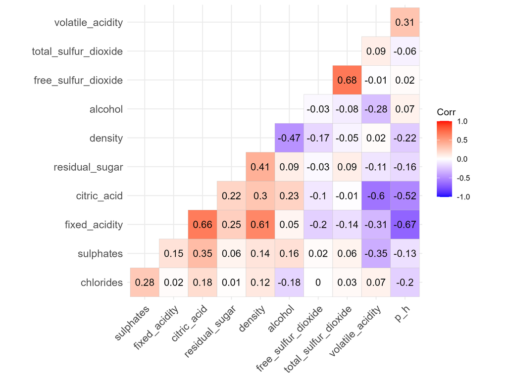

Here is an example of a PCA result:

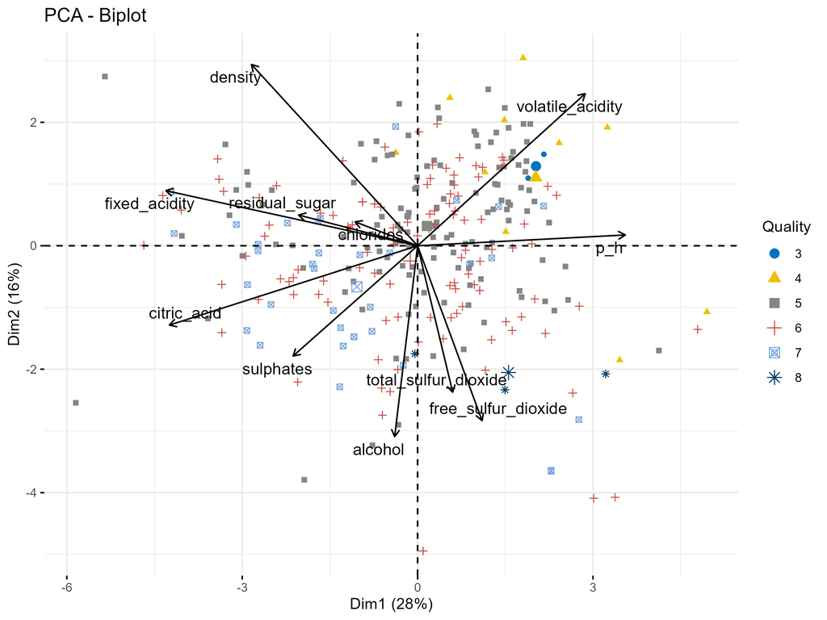

## 5 Reference

P. Cortez, A. Cerdeira, F. Almeida, T. Matos and J. Reis. Modeling wine preferences by data mining from physicochemical properties. In Decision Support Systems, Elsevier, 47(4):547-553, 2009.